# 1. Import drug screen data

#### 3.4.1.32 C0501131D08

🔍 Zoom In for Details

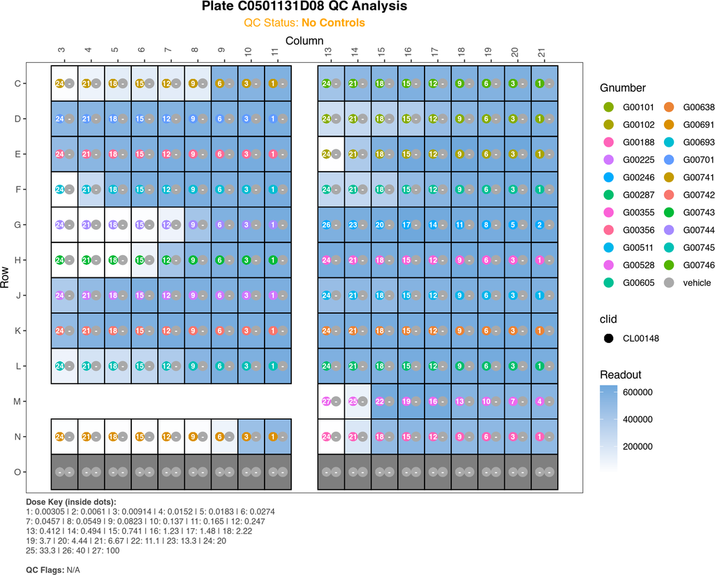

Before executing the pipeline, there exists a provision for manual alterations within the raw data. This allows for the manual modification of certain annotations and the correction of data as needed.

```r
# preview the annotation used in the preprocessing
drug_annotation_path <- file.path(wd, "data_annotation", "drug_annotation.csv")
drug_annotation <- if (file.exists(drug_annotation_path)) {
  fread(drug_annotation_path)
} else {
  get_drug_annotation_from_dt(data_imported)
}
data_imported <- annotate_dt_with_drug(data_imported, drug_annotation)
fwrite(drug_annotation, drug_annotation_path)
generate_datatable(drug_annotation)
```

|  | Gnumber | DrugName | drug_moa |
| --- | --- | --- | --- |
| 1 | G00778 | G00778 | PDE4A\|PDE4B\|PDE4C\|PDE4D |
| 2 | G00161 | BV6 | BIRC2\|XIAP |
| 3 | G00480 | PD 166285 dihydrochloride | SRC\|FGFR1 |
| 4 | G00122 | Verrucarin A | unknown |
| 5 | G00193 | 5-FLUOROURACIL | DNA |
| 6 | G00765 | A-196 | KMT5B |
| 7 | G00719 | ADS146185 | RORC |
| 8 | G00803 | AEB071 | PRKCs (multiple) |
| 9 | G00632 | AGI-6780 | IDH2 |
| 10 | G00133 | AKT inhibitor VIII | AKT1\|AKT2 |

[output cut: 166 more lines]

```r
cell_line_annotation_path <- file.path(wd, "data_annotation", "cell_line_annotation.csv")
cell_line_annotation <- if (file.exists(cell_line_annotation_path)) {
  fread(cell_line_annotation_path)
} else {
  get_cellline_annotation_from_dt(data_imported)
}
data_imported <- annotate_dt_with_cell_line(data_imported, cell_line_annotation)
fwrite(cell_line_annotation, cell_line_annotation_path)
generate_datatable(cell_line_annotation)
```

|  | clid | CellLineName | Tissue | parental_identifier | subtype | ReferenceDivisionTime |
| --- | --- | --- | --- | --- | --- | --- |
| 1 | CL00147 | NCI-H23 | Lung | NCI-H23 | Carcinoma Non-Small Cell | 37 |
| 2 | CL00148 | NCI-H358 | Lung | NCI-H358 | Carcinoma Non-Small Cell | 50 |

```r
qs_save(data_imported, file.path(wd, "gDR_data", "gDR_input.qs2"))
```